# BIOSTAT 707 Checkpoint 2

Author

Yifei Chen

Published

October 19, 2026

# AI-use statement

I used OpenAI Codex to assist with project planning, specific coding challenges, and improving the clarity of my academic writing. I independently selected the statistical models and followed the modeling and evaluation requirements provided in the assignment. During data preparation, Codex helped with reshaping and merging datasets, handling missing values, and improving reproducibility through relative file paths and additional data-cleaning summaries. It also generated the code for calculating time-series slopes, which I reviewed and incorporated into my analysis.

For model evaluation, my original approach involved manually selecting and recording cross-validation folds. I consulted Codex to improve this implementation, and it generated the cross-validation workflow based on the assignment requirements, including hyperparameter tuning, out-of-fold predictions, and LASSO variable-selection tracking. I was already familiar with techniques such as GridSearchCV, but used Codex to help organize the overall workflow. I also consulted Codex for specific preprocessing functions, GAM partial-effect calculations and visualizations, and troubleshooting the conditional logic for interpreting GAM curves. Additionally, Codex helped refine figure labels and suggested adding the Reproducibility and Saved Files section.

Codex was useful for improving coding efficiency, addressing technical challenges, and making the analysis more organized and reproducible. However, some generated code was unnecessarily complicated or required adjustments. I reviewed the suggested code, worked through the logic, tested the results, and checked intermediate outputs and visualizations before incorporating them into my report. The modeling choices, interpretation of results, and final analytical decisions remained my responsibility.

# 2.1 The modeling table

Checkpoint 2 uses only the 4,000 intensive care unit (ICU) stays in Set A and `data/Outcomes-a.txt`. The modeling table has one row per stay. Each row contains admission descriptors and summaries of measurements collected from hour 0 through hour 48. `In-hospital_death`, joined by `RecordID`, is the binary outcome. The data are from the [PhysioNet/CinC Challenge 2012](https://physionet.org/content/challenge-2012/1.0.0/) (Silva et al., 2012; citation at the end of this report).

**Show Python code**

```python
set_a_files = sorted((DATA_DIR / "set-a").glob("*.txt"), key=lambda p: int(p.stem))
outcome_path = DATA_DIR / "Outcomes-a.txt"
assert len(set_a_files) == EXPECTED_N, "Set A must contain 4,000 records."
assert outcome_path.exists(), "Outcomes-a.txt is missing."

def read_record(path):
    frame = pd.read_csv(path)
    assert list(frame.columns) == ["Time", "Parameter", "Value"]
    record_id = int(path.stem)
    embedded = frame.loc[frame["Parameter"].eq("RecordID"), "Value"]
    assert len(embedded) == 1 and int(embedded.iloc[0]) == record_id
    frame["RecordID"] = record_id
    return frame

long_raw = pd.concat([read_record(path) for path in set_a_files], ignore_index=True)
long_raw = long_raw.loc[~long_raw["Parameter"].eq("RecordID")].copy()
time_parts = long_raw["Time"].str.split(":", expand=True).astype(float)
long_raw["hour"] = time_parts[0] + time_parts[1] / 60
long_raw["Value_raw"] = pd.to_numeric(long_raw["Value"], errors="coerce")
long_raw = long_raw[["RecordID", "hour", "Parameter", "Value_raw"]]
outcomes = pd.read_csv(outcome_path)[
    ["RecordID", "SAPS-I", "SOFA", "In-hospital_death"]
].copy()
assert len(outcomes) == EXPECTED_N and outcomes["RecordID"].nunique() == EXPECTED_N
assert set(outcomes["In-hospital_death"].unique()).issubset({0, 1})
assert long_raw["hour"].between(0, 48).all()
```

The Checkpoint 1 rule that negative values are invalid is retained. For modeling, I additionally recode values outside broad physiologic screening ranges as missing. This revises Checkpoint 1, where nonnegative outliers were flagged but retained. Zero height and zero weight are now missing. The original values remain in `Value_raw`, which makes every change auditable.

**Show Python code**

```python
bounds = pd.DataFrame([
    ("Age", 18, 120), ("Height", 100, 230), ("Weight", 20, 400),
    ("HR", 20, 250), ("RespRate", 4, 60), ("Temp", 30, 43),
    ("pH", 6.8, 7.8), ("GCS", 3, 15), ("FiO2", .20, 1),
    ("SaO2", 50, 100), ("Gender", 0, 1), ("ICUType", 1, 4),
], columns=["Parameter", "lower", "upper"])
long = long_raw.merge(bounds, on="Parameter", how="left")
long["negative_invalid"] = long["Value_raw"].lt(0)
long["outside_screen"] = (
    long["lower"].notna()
    & (long["Value_raw"].lt(long["lower"]) | long["Value_raw"].gt(long["upper"]))
    & ~long["negative_invalid"]
)
long["Value"] = long["Value_raw"].mask(
    long["negative_invalid"] | long["outside_screen"]
)
cleaning_summary = (
    long.loc[long["negative_invalid"] | long["outside_screen"]]
    .groupby("Parameter", as_index=False)
    .agg(negative_codes=("negative_invalid", "sum"),
         outside_screening_range=("outside_screen", "sum"),
         total_set_missing=("Value_raw", "size"))
    .sort_values("total_set_missing", ascending=False)
)
display(cleaning_summary.style.hide(axis="index").set_caption(
    "Table 1. Values recoded as missing before feature construction"
))
```

Table 1: Table 1. Values recoded as missing before feature construction

| Parameter | negative_codes | outside_screening_range | total_set_missing |
| --- | --- | --- | --- |
| Height | 1894 | 16 | 1910 |
| Weight | 326 | 235 | 561 |
| Temp | 24 | 109 | 133 |
| RespRate | 0 | 68 | 68 |
| HR | 0 | 17 | 17 |
| pH | 0 | 11 | 11 |
| SaO2 | 0 | 8 | 8 |
| Age | 0 | 6 | 6 |
| Gender | 3 | 0 | 3 |

Table 1 documents every cleaning change. Negative codes account for most changes, while `outside_screening_range` identifies the additional broad screening decisions used for modeling.

**Show Python code**

```python
static_parameters = ["Age", "Gender", "Height", "ICUType", "Weight"]
series_parameters = sorted(
    set(long["Parameter"].unique()) - {"Age", "Gender", "Height", "ICUType"}
)
static = (
    long.loc[long["hour"].eq(0) & long["Parameter"].isin(static_parameters)]
    .sort_values(["RecordID", "Parameter", "hour"])
    .drop_duplicates(["RecordID", "Parameter"], keep="first")
    .pivot(index="RecordID", columns="Parameter", values="Value")
    .rename(columns={"Weight": "Weight_admission"})
)
series = long.loc[long["Parameter"].isin(series_parameters)].copy()
series = series.sort_values(["RecordID", "Parameter", "hour"])
valid = series.dropna(subset=["Value"]).copy()
valid["time_value"] = valid["hour"] * valid["Value"]
valid["time_squared"] = valid["hour"] ** 2
series_summary = valid.groupby(["RecordID", "Parameter"]).agg(
    count=("Value", "size"), last=("Value", "last"),
    minimum=("Value", "min"), maximum=("Value", "max"), mean=("Value", "mean"),
    sum_time=("hour", "sum"), sum_value=("Value", "sum"),
    sum_time_value=("time_value", "sum"), sum_time_squared=("time_squared", "sum"),
)
denominator = series_summary["count"] * series_summary["sum_time_squared"] - series_summary["sum_time"] ** 2
series_summary["slope"] = (
    series_summary["count"] * series_summary["sum_time_value"]
    - series_summary["sum_time"] * series_summary["sum_value"]
) / denominator.replace(0, np.nan)
series_summary = series_summary[["count", "last", "minimum", "maximum", "mean", "slope"]]
complete_index = pd.MultiIndex.from_product(
    [outcomes["RecordID"], series_parameters], names=["RecordID", "Parameter"]
)
series_summary = series_summary.reindex(complete_index)
series_summary["count"] = series_summary["count"].fillna(0).astype(int)
series_summary["never"] = series_summary["count"].eq(0).astype(int)
series_wide = series_summary.unstack("Parameter")
series_wide.columns = [f"{parameter}_{stat}" for stat, parameter in series_wide.columns]
modeling = (
    outcomes[["RecordID"]].set_index("RecordID")
    .join(static, how="left").join(series_wide, how="left")
    .join(outcomes.set_index("RecordID")[["SAPS-I", "SOFA", "In-hospital_death"]])
    .reset_index()
)
modeling["SAPS-I"] = modeling["SAPS-I"].replace(-1, np.nan)
modeling["SOFA"] = modeling["SOFA"].replace(-1, np.nan)
modeling["outcome"] = modeling.pop("In-hospital_death").astype(int)
for name in ["Height", "Weight_admission", "Age"]:
    modeling[f"{name}_missing"] = modeling[name].isna().astype(int)
modeling["Gender"] = modeling["Gender"].map({0: "Female", 1: "Male"}).fillna("Unknown")
modeling["ICUType"] = modeling["ICUType"].map({
    1: "Coronary care", 2: "Cardiac surgery recovery",
    3: "Medical ICU", 4: "Surgical ICU",
}).fillna("Unknown")
assert len(modeling) == EXPECTED_N
assert modeling["RecordID"].nunique() == EXPECTED_N
assert modeling["outcome"].notna().all()
modeling.to_csv(OUTPUT_DIR / "cp2_modeling_table.csv", index=False)
n_deaths = int(modeling["outcome"].sum())
death_rate = modeling["outcome"].mean()
display(Markdown(
    f"The modeling table contains **{len(modeling):,} stays**, **{n_deaths:,} deaths**, "
    f"and an in-hospital mortality rate of **{death_rate:.1%}**. Its one-row-per-stay "
    "layout is checked explicitly, so ordinary stratified folds are also folds by stay."
))
```

The modeling table contains **4,000 stays**, **554 deaths**, and an in-hospital mortality rate of **13.9%**. Its one-row-per-stay layout is checked explicitly, so ordinary stratified folds are also folds by stay.

# 2.2 Predictors

Only data from hours 0 through 48 are predictors. `RecordID` is an identifier; length of stay and survival are not read into the modeling table; and SAPS-I and SOFA are reserved as benchmarks. ICU type is categorical. The time-series features retain current level, range, average level, linear direction, measurement intensity, and whether a variable was never measured.

**Show Python code**

```python
predictor_groups = pd.DataFrame([
    ("Admission descriptors", 5, "Baseline age, sex, body size, and ICU context."),
    ("Last, minimum, maximum, and mean", 4 * len(series_parameters), "Level and extremes summarize severity over 48 hours."),
    ("Slope", len(series_parameters), "Direction may distinguish improvement from deterioration."),
    ("Measurement count", len(series_parameters), "Monitoring intensity can reflect clinical concern."),
    ("Never-measured indicators", len(series_parameters) + 3, "Missingness can be informative."),
], columns=["Group", "Count", "Clinical reason"])
excluded_columns = ["RecordID", "outcome", "SAPS-I", "SOFA"]
feature_columns = [name for name in modeling.columns if name not in excluded_columns]
categorical_features = ["Gender", "ICUType"]
numeric_features = [name for name in feature_columns if name not in categorical_features]
X, y = modeling[feature_columns].copy(), modeling["outcome"].to_numpy()
predictor_groups.loc[len(predictor_groups)] = [
    "Total before categorical expansion", len(feature_columns),
    "Full candidate set used by Models 1 and 3."
]
display(predictor_groups.style.hide(axis="index").set_caption(
    "Table 2. Predictor groups and clinical rationale"
))
```

Table 2: Table 2. Predictor groups and clinical rationale

| Group | Count | Clinical reason |
| --- | --- | --- |
| Admission descriptors | 5 | Baseline age, sex, body size, and ICU context. |
| Last, minimum, maximum, and mean | 148 | Level and extremes summarize severity over 48 hours. |
| Slope | 37 | Direction may distinguish improvement from deterioration. |
| Measurement count | 37 | Monitoring intensity can reflect clinical concern. |
| Never-measured indicators | 40 | Missingness can be informative. |
| Total before categorical expansion | 267 | Full candidate set used by Models 1 and 3. |

The count and never-measured features retain missingness information before median imputation. No observed time-series parameter was dropped for being rarely measured; the exclusion threshold was zero valid stays. This avoids outcome-informed screening before CV. Constant columns are removed using training data only.

# 2.3 Cross-validation design

I use five-fold stratified cross-validation. Every model and both benchmarks use the same outer folds. LASSO and random-forest tuning use three-fold CV inside each outer training fold and minimize Brier score. Median imputation, constant-column removal, scaling, one-hot encoding, and tuning are fit within training data and then applied to validation or held-out data.

**Show Python code**

```python
outer_cv = StratifiedKFold(n_splits=OUTER_K, shuffle=True, random_state=SEED)
outer_splits = list(outer_cv.split(X, y))
outer_fold = np.empty(len(y), dtype=int)
for fold, (_, test_index) in enumerate(outer_splits, start=1):
    outer_fold[test_index] = fold
fold_balance = (
    pd.DataFrame({"fold": outer_fold, "outcome": y}).value_counts(["fold", "outcome"])
    .unstack(fill_value=0).rename(columns={0: "Survived", 1: "Died"}).reset_index()
)
fold_balance["Death rate"] = fold_balance["Died"] / (fold_balance["Survived"] + fold_balance["Died"])
display(fold_balance.style.hide(axis="index").format({"Death rate": "{:.1%}"}).set_caption(
    "Table 3. Fixed outer folds shared by every model and benchmark"
))
```

Table 3: Table 3. Fixed outer folds shared by every model and benchmark

| fold | Survived | Died | Death rate |
| --- | --- | --- | --- |
| 1 | 690 | 110 | 13.8% |
| 2 | 689 | 111 | 13.9% |
| 3 | 689 | 111 | 13.9% |
| 4 | 689 | 111 | 13.9% |
| 5 | 689 | 111 | 13.9% |

Table 3 confirms successful stratification. Because there is one row per stay, no stay can occur in both training and held-out data.

**Show Python code**

```python
category_levels = [
    ["Female", "Male", "Unknown"],
    ["Coronary care", "Cardiac surgery recovery", "Medical ICU", "Surgical ICU", "Unknown"],
]
def make_preprocessor(scale_numeric):
    steps = [("impute", SimpleImputer(strategy="median"))]
    if scale_numeric:
        steps.append(("scale", StandardScaler()))
    return ColumnTransformer([
        ("numeric", Pipeline(steps), numeric_features),
        ("categorical", OneHotEncoder(categories=category_levels, handle_unknown="ignore", sparse_output=False), categorical_features),
    ], sparse_threshold=0, verbose_feature_names_out=False)

def make_lasso_pipeline():
    return Pipeline([
        ("preprocess", make_preprocessor(True)), ("remove_constant", VarianceThreshold()),
        ("model", LogisticRegression(l1_ratio=1, solver="saga", max_iter=3000, random_state=SEED)),
    ])

def make_forest_pipeline():
    return Pipeline([
        ("preprocess", make_preprocessor(False)), ("remove_constant", VarianceThreshold()),
        ("model", RandomForestClassifier(n_estimators=250, random_state=SEED, n_jobs=-1, class_weight="balanced_subsample")),
    ])

gam_continuous = [
    "Age", "HR_mean", "Temp_mean", "RespRate_mean", "MAP_mean",
    "Creatinine_last", "Lactate_last", "GCS_last", "BUN_last", "pH_last",
    "Urine_mean", "WBC_last",
]
gam_linear, gam_categories = ["MechVent_maximum"], ["Gender", "ICUType"]

def fit_gam_preprocessor(frame):
    imputer = SimpleImputer(strategy="median")
    scaler = StandardScaler().fit(imputer.fit_transform(frame[gam_continuous]))
    linear_imputer = SimpleImputer(strategy="median").fit(frame[gam_linear])
    encoder = OneHotEncoder(categories=category_levels, handle_unknown="ignore", sparse_output=False).fit(frame[gam_categories])
    return {"continuous_imputer": imputer, "continuous_scaler": scaler,
            "linear_imputer": linear_imputer, "category_encoder": encoder}

def apply_gam_preprocessor(frame, prep):
    continuous = prep["continuous_scaler"].transform(prep["continuous_imputer"].transform(frame[gam_continuous]))
    linear = prep["linear_imputer"].transform(frame[gam_linear])
    categories = prep["category_encoder"].transform(frame[gam_categories])
    return np.column_stack([continuous, linear, categories])

def gam_terms():
    term = s(0, n_splines=4)
    for index in range(1, len(gam_continuous)):
        term += s(index, n_splines=4)
    for index in range(len(gam_continuous), len(gam_continuous) + 9):
        term += l(index)
    return term
```

# 2.4 Model 1: regularized logistic regression

Model 1 is logistic regression with a least absolute shrinkage and selection operator (LASSO) penalty. LASSO is appropriate because the engineered feature set is large and correlated: it shrinks weak coefficients to zero and produces a more compact model. Twelve inverse penalty strengths (`C`) from 0.0032 to 3.1623 are compared within each outer training set. Numeric predictors are standardized; categorical levels are represented by binary indicators.

**Show Python code**

```python
C_GRID = np.logspace(-2.5, 0.5, 12)
FOREST_GRID = {"model__max_features": ["sqrt", 0.5], "model__min_samples_leaf": [5, 20]}
model_names = ["LASSO", "GAM", "Random forest", "SAPS-I", "SOFA"]
oof = pd.DataFrame({
    "RecordID": modeling["RecordID"], "outcome": y, "fold": outer_fold,
    "LASSO": np.nan, "GAM": np.nan, "Random forest": np.nan,
    "SAPS-I": modeling["SAPS-I"], "SOFA": modeling["SOFA"],
})
lasso_outer, lasso_selected, forest_outer = [], [], []

for fold, (train_index, test_index) in enumerate(outer_splits, start=1):
    X_train, X_test, y_train = X.iloc[train_index], X.iloc[test_index], y[train_index]
    inner_cv = StratifiedKFold(n_splits=INNER_K, shuffle=True, random_state=8000 + fold)
    lasso_search = GridSearchCV(
        make_lasso_pipeline(), {"model__C": C_GRID}, scoring="neg_brier_score",
        cv=inner_cv, n_jobs=-1, refit=True,
    ).fit(X_train, y_train)
    oof.loc[test_index, "LASSO"] = lasso_search.predict_proba(X_test)[:, 1]
    lasso_fit = lasso_search.best_estimator_
    all_names = lasso_fit.named_steps["preprocess"].get_feature_names_out()
    kept_names = all_names[lasso_fit.named_steps["remove_constant"].get_support()]
    coefficients = lasso_fit.named_steps["model"].coef_.ravel()
    selected = set(kept_names[~np.isclose(coefficients, 0)])
    lasso_selected.append(selected)
    lasso_outer.append({"Fold": fold, "C": lasso_search.best_params_["model__C"],
                        "Selected predictors": len(selected)})

    gam_prep = fit_gam_preprocessor(modeling.iloc[train_index])
    gam_train = apply_gam_preprocessor(modeling.iloc[train_index], gam_prep)
    gam_test = apply_gam_preprocessor(modeling.iloc[test_index], gam_prep)
    gam_fit = LogisticGAM(gam_terms(), lam=0.6, max_iter=300).fit(gam_train, y_train)
    oof.loc[test_index, "GAM"] = gam_fit.predict_proba(gam_test)

    forest_search = GridSearchCV(
        make_forest_pipeline(), FOREST_GRID, scoring="neg_brier_score",
        cv=inner_cv, n_jobs=-1, refit=True,
    ).fit(X_train, y_train)
    oof.loc[test_index, "Random forest"] = forest_search.predict_proba(X_test)[:, 1]
    forest_outer.append({
        "Fold": fold, "max_features": forest_search.best_params_["model__max_features"],
        "min_samples_leaf": forest_search.best_params_["model__min_samples_leaf"],
        "Inner mean Brier score": -forest_search.best_score_,
    })
assert oof[["LASSO", "GAM", "Random forest"]].notna().all().all()
```

**Show Python code**

```python
full_inner_cv = StratifiedKFold(n_splits=OUTER_K, shuffle=True, random_state=SEED)
final_lasso_search = GridSearchCV(
    make_lasso_pipeline(), {"model__C": C_GRID}, scoring="neg_brier_score",
    cv=full_inner_cv, n_jobs=-1, refit=True,
).fit(X, y)
final_lasso = final_lasso_search.best_estimator_
final_gam_prep = fit_gam_preprocessor(modeling)
final_gam_X = apply_gam_preprocessor(modeling, final_gam_prep)
final_gam = LogisticGAM(gam_terms(), lam=0.6, max_iter=300).fit(final_gam_X, y)
final_forest_search = GridSearchCV(
    make_forest_pipeline(), FOREST_GRID, scoring="neg_brier_score",
    cv=full_inner_cv, n_jobs=-1, refit=True,
).fit(X, y)
final_forest = final_forest_search.best_estimator_

all_final_names = final_lasso.named_steps["preprocess"].get_feature_names_out()
final_names = all_final_names[final_lasso.named_steps["remove_constant"].get_support()]
final_values = final_lasso.named_steps["model"].coef_.ravel()
final_coefficients = pd.DataFrame({"Predictor": final_names, "Coefficient": final_values})
final_coefficients = final_coefficients.loc[~np.isclose(final_coefficients["Coefficient"], 0)].copy()
final_coefficients["Folds selected"] = final_coefficients["Predictor"].map(
    lambda name: sum(name in selected for selected in lasso_selected)
)
final_coefficients["Absolute coefficient"] = final_coefficients["Coefficient"].abs()
final_coefficients = final_coefficients.sort_values("Absolute coefficient", ascending=False)
```

**Show Python code**

```python
lasso_outer_table = pd.DataFrame(lasso_outer)
display(lasso_outer_table.style.hide(axis="index").format({"C": "{:.4f}"}).set_caption(
    "Table 4. LASSO tuning and retained predictor count by outer fold"
))
```

Table 4: Table 4. LASSO tuning and retained predictor count by outer fold

| Fold | C | Selected predictors |
| --- | --- | --- |
| 1 | 0.0059 | 267 |
| 2 | 0.0059 | 267 |
| 3 | 0.0059 | 267 |
| 4 | 0.0059 | 267 |
| 5 | 0.0059 | 267 |

**Show Python code**

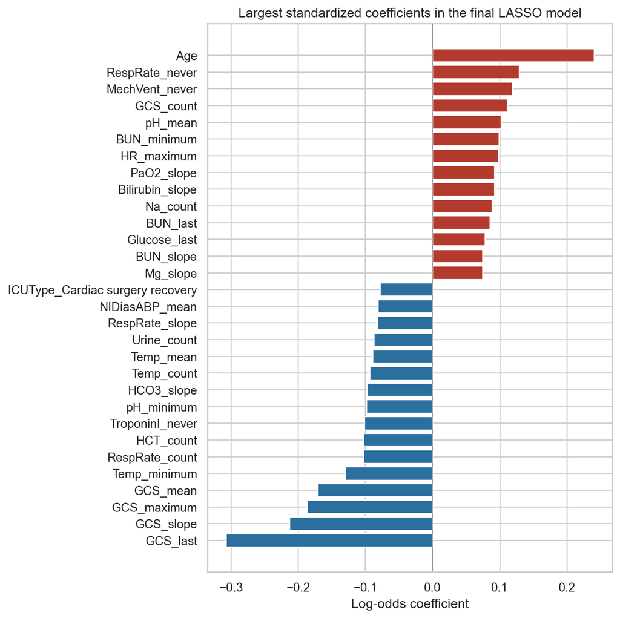

```python
coefficient_plot = final_coefficients.head(30).sort_values("Coefficient")
colors = np.where(coefficient_plot["Coefficient"].gt(0), "#b33b2e", "#2b6f9e")
fig, ax = plt.subplots(figsize=(8, 8))
ax.barh(coefficient_plot["Predictor"], coefficient_plot["Coefficient"], color=colors)
ax.axvline(0, color="grey", linewidth=.8)
ax.set(title="Largest standardized coefficients in the final LASSO model",
       xlabel="Log-odds coefficient", ylabel="")
plt.tight_layout(); plt.show()
```

Figure 1 compares numeric predictors after standardization and categorical indicator changes on their encoded scale. Positive coefficients correspond to higher modeled mortality risk and negative coefficients to lower risk, conditional on other retained predictors; the associations are not causal.

**Show Python code**

```python
display(final_coefficients[["Predictor", "Coefficient", "Folds selected"]]
        .style.hide(axis="index").format({"Coefficient": "{:.4f}"})
        .set_caption("Table 5. Predictors retained by the final LASSO and outer-fold stability"))
```

Table 5: Table 5. Predictors retained by the final LASSO and outer-fold stability

| Predictor | Coefficient | Folds selected |
| --- | --- | --- |
| GCS_last | -0.3073 | 5 |
| Age | 0.2403 | 5 |
| GCS_slope | -0.2128 | 5 |
| GCS_maximum | -0.1865 | 5 |
| GCS_mean | -0.1709 | 5 |
| Temp_minimum | -0.1295 | 5 |
| RespRate_never | 0.1290 | 5 |
| MechVent_never | 0.1187 | 5 |
| GCS_count | 0.1115 | 5 |
| RespRate_count | -0.1027 | 5 |
| HCT_count | -0.1025 | 5 |
| pH_mean | 0.1018 | 5 |
| TroponinI_never | -0.1014 | 5 |
| BUN_minimum | 0.0990 | 5 |
| pH_minimum | -0.0986 | 5 |
| HR_maximum | 0.0985 | 5 |
| HCO3_slope | -0.0969 | 5 |
| Temp_count | -0.0935 | 5 |
| PaO2_slope | 0.0925 | 5 |
| Bilirubin_slope | 0.0922 | 5 |
| Temp_mean | -0.0894 | 5 |
| Na_count | 0.0886 | 5 |
| Urine_count | -0.0872 | 5 |
| BUN_last | 0.0853 | 5 |
| RespRate_slope | -0.0819 | 5 |
| NIDiasABP_mean | -0.0814 | 5 |
| Glucose_last | 0.0783 | 5 |
| ICUType_Cardiac surgery recovery | -0.0779 | 5 |
| BUN_slope | 0.0746 | 5 |
| Mg_slope | 0.0744 | 5 |

[output cut: 237 more lines]

Table 5 lists every predictor retained after refitting on all Set A. Features selected in all five outer fits are more stable than those selected in only one, although correlated features can lower apparent stability.

# 2.5 Model 2: non-linear effects with a GAM

Model 2 is a logistic generalized additive model (GAM). Twelve continuous predictors were selected before fitting on clinical grounds to represent age, vital signs, neurologic status, renal function, acid-base status, urine output, and inflammation. Mechanical ventilation, sex, and ICU type enter as linear or categorical indicator terms. Four basis functions per smooth and a fixed smoothing penalty of 0.6 limit flexibility without using held-out outcomes.

**Show Python code**

```python
gam_predictor_table = pd.DataFrame({
    "Predictor": gam_continuous + gam_linear + gam_categories,
    "Role": ["Smooth continuous effect"] * len(gam_continuous)
            + ["Linear binary effect"] + ["Categorical effect"] * 2,
})
display(gam_predictor_table.style.hide(axis="index").set_caption(
    "Table 6. Fifteen clinically selected GAM predictors"
))
```

Table 6: Table 6. Fifteen clinically selected GAM predictors

| Predictor | Role |
| --- | --- |
| Age | Smooth continuous effect |
| HR_mean | Smooth continuous effect |
| Temp_mean | Smooth continuous effect |
| RespRate_mean | Smooth continuous effect |
| MAP_mean | Smooth continuous effect |
| Creatinine_last | Smooth continuous effect |
| Lactate_last | Smooth continuous effect |
| GCS_last | Smooth continuous effect |
| BUN_last | Smooth continuous effect |
| pH_last | Smooth continuous effect |
| Urine_mean | Smooth continuous effect |
| WBC_last | Smooth continuous effect |
| MechVent_maximum | Linear binary effect |
| Gender | Categorical effect |
| ICUType | Categorical effect |

The restricted set makes the GAM interpretable and reduces unstable smooths. The choices were fixed before examining outer-fold performance.

**Show Python code**

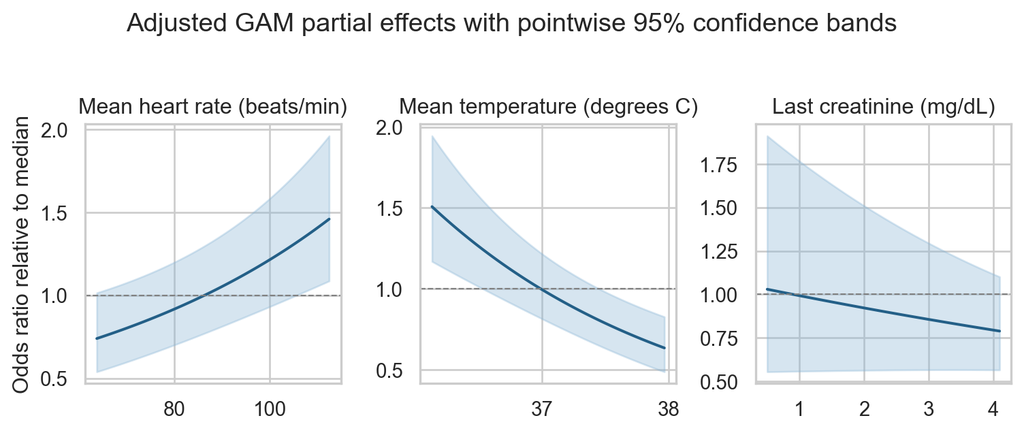

```python
partial_variables = [
    ("HR_mean", "Mean heart rate (beats/min)"),
    ("Temp_mean", "Mean temperature (degrees C)"),
    ("Creatinine_last", "Last creatinine (mg/dL)"),
]
partial_rows, shape_rows = [], []
for variable, label in partial_variables:
    term_index = gam_continuous.index(variable)
    observed = modeling[variable].dropna()
    raw_grid = np.linspace(observed.quantile(.05), observed.quantile(.95), 100)
    reference_raw = observed.median()
    mean = final_gam_prep["continuous_scaler"].mean_[term_index]
    scale = final_gam_prep["continuous_scaler"].scale_[term_index]
    reference = np.nanmedian(final_gam_X, axis=0)
    grid_matrix = np.tile(reference, (len(raw_grid), 1))
    grid_matrix[:, term_index] = (raw_grid - mean) / scale
    reference_matrix = reference.reshape(1, -1).copy()
    reference_matrix[0, term_index] = (reference_raw - mean) / scale
    effect, interval = final_gam.partial_dependence(term=term_index, X=grid_matrix, width=.95)
    reference_effect = float(final_gam.partial_dependence(term=term_index, X=reference_matrix)[0])
    odds_ratio = np.exp(effect - reference_effect)
    partial_rows.append(pd.DataFrame({
        "variable": variable, "label": label, "value": raw_grid,
        "odds_ratio": odds_ratio, "lower": np.exp(interval[:, 0] - reference_effect),
        "upper": np.exp(interval[:, 1] - reference_effect),
    }))
    coef_indices = final_gam.terms.get_coef_indices(term_index)
    edf = float(final_gam.statistics_["edof_per_coef"][coef_indices].sum())
    left, middle, right = odds_ratio[0], odds_ratio[len(odds_ratio)//2], odds_ratio[-1]
    if edf < 1.3:
        direction = "increasing" if right > left else "decreasing"
        shape = f"approximately linear and {direction}"
    elif left > middle and right > middle:
        shape = "curved, with higher estimated risk at both low and high values"
    elif right > left:
        shape = "curved, with estimated risk generally increasing across the range"
    else:
        shape = "curved, with estimated risk generally decreasing across the range"
    shape_rows.append({"Predictor": label, "EDF": edf, "Assessment": shape})

partial_effects = pd.concat(partial_rows, ignore_index=True)
fig, axes = plt.subplots(1, 3, figsize=(8, 3.2))
for ax, (variable, label) in zip(axes, partial_variables):
    values = partial_effects.loc[partial_effects["variable"].eq(variable)]
    ax.fill_between(values["value"], values["lower"], values["upper"], color="#8ab6d6", alpha=.35)
    ax.plot(values["value"], values["odds_ratio"], color="#235f87")
    ax.axhline(1, linestyle="--", color="grey", linewidth=.8)
    ax.set_title(label); ax.set_xlabel("")
axes[0].set_ylabel("Odds ratio relative to median")
fig.suptitle("Adjusted GAM partial effects with pointwise 95% confidence bands", y=1.03)
plt.tight_layout(); plt.show()
```

**Show Python code**

```python
shape_table = pd.DataFrame(shape_rows)
display(shape_table.style.hide(axis="index").format({"EDF": "{:.2f}"}).set_caption(
    "Table 7. Shape assessment for the plotted GAM effects"
))
clinical_text = {
    "Mean heart rate (beats/min)": "The increasing pattern is clinically plausible because tachycardia can reflect physiologic stress.",
    "Mean temperature (degrees C)": "The decreasing pattern suggests higher risk at lower temperatures, which is plausible for severe hypothermia; it does not show a U-shape over the central observed range.",
    "Last creatinine (mg/dL)": "The nearly flat, slightly decreasing pattern does not match the usual expectation that renal dysfunction raises risk, so it should not receive a strong clinical interpretation after multivariable adjustment.",
}
sentences = [f"- **{row['Predictor']}** is {row['Assessment']} (EDF {row['EDF']:.2f}). {clinical_text[row['Predictor']]}" for row in shape_rows]
display(Markdown("\n".join(sentences)))
```

Table 7: Table 7. Shape assessment for the plotted GAM effects

| Predictor | EDF | Assessment |
| --- | --- | --- |
| Mean heart rate (beats/min) | 1.12 | approximately linear and increasing |
| Mean temperature (degrees C) | 1.12 | approximately linear and decreasing |
| Last creatinine (mg/dL) | 1.28 | approximately linear and decreasing |

- **Mean heart rate (beats/min)** is approximately linear and increasing (EDF 1.12). The increasing pattern is clinically plausible because tachycardia can reflect physiologic stress.

- **Mean temperature (degrees C)** is approximately linear and decreasing (EDF 1.12). The decreasing pattern suggests higher risk at lower temperatures, which is plausible for severe hypothermia; it does not show a U-shape over the central observed range.

- **Last creatinine (mg/dL)** is approximately linear and decreasing (EDF 1.28). The nearly flat, slightly decreasing pattern does not match the usual expectation that renal dysfunction raises risk, so it should not receive a strong clinical interpretation after multivariable adjustment.

Figure 2 and Table 7 describe the adjusted shape of each selected predictor. Confidence bands widen where observations are sparse, so curve ends should be interpreted cautiously.

# 2.6 Model 3: tree ensemble

Model 3 is a probability random forest using all candidate predictors. The nested search compares `sqrt(p)` with 50% of features at each split and minimum leaf sizes of 5 and 20, using 250 trees per fit. Missing values are median-imputed within each training split. No early stopping is used.

**Show Python code**

```python
forest_choices = pd.DataFrame(forest_outer)
display(forest_choices.style.hide(axis="index").format({"Inner mean Brier score": "{:.4f}"})
        .set_caption("Table 8. Random-forest settings chosen by nested tuning"))
```

Table 8: Table 8. Random-forest settings chosen by nested tuning

| Fold | max_features | min_samples_leaf | Inner mean Brier score |
| --- | --- | --- | --- |
| 1 | 0.500000 | 5 | 0.0997 |
| 2 | 0.500000 | 5 | 0.0978 |
| 3 | 0.500000 | 5 | 0.0972 |
| 4 | 0.500000 | 5 | 0.0978 |
| 5 | 0.500000 | 5 | 0.0987 |

Table 8 shows whether tuning consistently favors the same feature sampling and terminal-node regularization across outer folds.

# 2.7 Comparison and choice of final model

**Show Python code**

```python
fold_rows = []
for model_name in model_names:
    for fold in range(1, OUTER_K + 1):
        mask = oof["fold"].eq(fold) & oof[model_name].notna()
        fold_rows.append({"Model": model_name, "Fold": fold,
                          "AUROC": roc_auc_score(oof.loc[mask, "outcome"], oof.loc[mask, model_name])})
fold_auc = pd.DataFrame(fold_rows)
auc_summary = (fold_auc.groupby("Model")["AUROC"].agg(**{"Mean AUROC": "mean", "SD AUROC": "std"}).reset_index())
comparison_table = (
    fold_auc.pivot(index="Model", columns="Fold", values="AUROC")
    .rename(columns=lambda value: f"Fold {value}").reset_index()
    .merge(auc_summary, on="Model").sort_values("Mean AUROC", ascending=False)
)
display(comparison_table.style.hide(axis="index").format(
    {column: "{:.3f}" for column in comparison_table.columns if column != "Model"})
    .set_caption("Table 9. Outer-fold AUROC for three models and two benchmarks"))
```

Table 9: Table 9. Outer-fold AUROC for three models and two benchmarks

| Model | Fold 1 | Fold 2 | Fold 3 | Fold 4 | Fold 5 | Mean AUROC | SD AUROC |
| --- | --- | --- | --- | --- | --- | --- | --- |
| Random forest | 0.857 | 0.846 | 0.829 | 0.849 | 0.868 | 0.850 | 0.015 |
| LASSO | 0.858 | 0.853 | 0.824 | 0.857 | 0.858 | 0.850 | 0.015 |
| GAM | 0.842 | 0.833 | 0.800 | 0.841 | 0.845 | 0.832 | 0.019 |
| SAPS-I | 0.677 | 0.665 | 0.637 | 0.620 | 0.650 | 0.650 | 0.022 |
| SOFA | 0.617 | 0.639 | 0.610 | 0.616 | 0.632 | 0.623 | 0.012 |

Table 9 compares every approach on the same held-out stays. Fold-to-fold variation provides context for whether a small mean AUROC difference is meaningful.

**Show Python code**

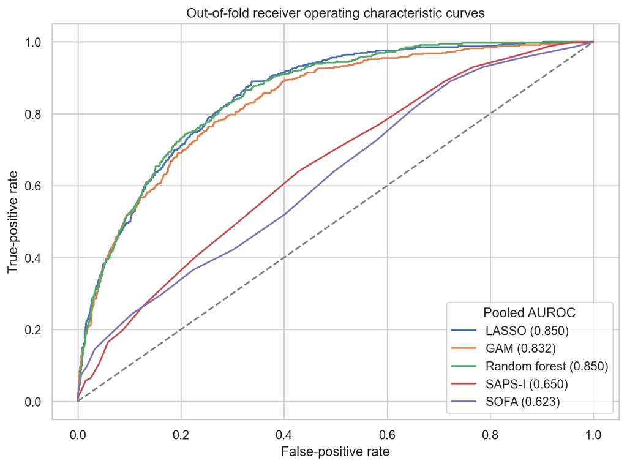

```python
fig, ax = plt.subplots(figsize=(8, 6))
for model_name in model_names:
    mask = oof[model_name].notna()
    fpr, tpr, _ = roc_curve(oof.loc[mask, "outcome"], oof.loc[mask, model_name])
    pooled_auc = roc_auc_score(oof.loc[mask, "outcome"], oof.loc[mask, model_name])
    ax.plot(fpr, tpr, label=f"{model_name} ({pooled_auc:.3f})")
ax.plot([0, 1], [0, 1], linestyle="--", color="grey")
ax.set(xlabel="False-positive rate", ylabel="True-positive rate",
       title="Out-of-fold receiver operating characteristic curves")
ax.legend(title="Pooled AUROC", loc="lower right")
plt.tight_layout(); plt.show()
```

Figure 3 shows discrimination over all thresholds. Curves closer to the upper left rank deaths above survivors more consistently; overlap indicates similar discrimination.

**Show Python code**

```python
candidate_summary = auc_summary.loc[auc_summary["Model"].isin(["LASSO", "GAM", "Random forest"])].sort_values("Mean AUROC", ascending=False)
benchmark_summary = auc_summary.loc[auc_summary["Model"].isin(["SAPS-I", "SOFA"])].sort_values("Mean AUROC", ascending=False)
best_model, best_benchmark = candidate_summary.iloc[0], benchmark_summary.iloc[0]
difference = best_model["Mean AUROC"] - best_benchmark["Mean AUROC"]
benchmark_sd = best_benchmark["SD AUROC"]
if best_model["Model"] == "LASSO":
    final_bundle = {"model_name": "LASSO", "model": final_lasso,
                    "feature_columns": feature_columns, "feature_window_hours": (0, 48)}
elif best_model["Model"] == "GAM":
    final_bundle = {"model_name": "GAM", "model": final_gam,
                    "preprocessor": final_gam_prep, "continuous_features": gam_continuous,
                    "linear_features": gam_linear, "categorical_features": gam_categories,
                    "feature_window_hours": (0, 48)}
else:
    final_bundle = {"model_name": "Random forest", "model": final_forest,
                    "feature_columns": feature_columns, "feature_window_hours": (0, 48)}
joblib.dump(final_bundle, OUTPUT_DIR / "cp2_final_model.joblib")
oof.to_csv(OUTPUT_DIR / "cp2_oof_predictions.csv", index=False)
fold_auc.to_csv(OUTPUT_DIR / "cp2_cv_results.csv", index=False)
variation_statement = "larger than" if difference > benchmark_sd else "not larger than"
display(Markdown(
    f"The best fitted model was **{best_model['Model']}** with mean AUROC **{best_model['Mean AUROC']:.3f}** "
    f"(fold SD **{best_model['SD AUROC']:.3f}**). The stronger benchmark was **{best_benchmark['Model']}** "
    f"with mean AUROC **{best_benchmark['Mean AUROC']:.3f}** (fold SD **{benchmark_sd:.3f}**). "
    f"The difference of **{difference:.3f}** was **{variation_statement}** the benchmark's fold-to-fold SD. "
    "I selected the highest mean-AUROC model and refit it on all Set A because it offered the strongest "
    "observed discrimination; simplicity and interpretability remain relevant when differences are small."
))
```

The best fitted model was **Random forest** with mean AUROC **0.850** (fold SD **0.015**). The stronger benchmark was **SAPS-I** with mean AUROC **0.650** (fold SD **0.022**). The difference of **0.200** was **larger than** the benchmark’s fold-to-fold SD. I selected the highest mean-AUROC model and refit it on all Set A because it offered the strongest observed discrimination; simplicity and interpretability remain relevant when differences are small.

The saved bundle contains the fitted preprocessing required by the selected model. Calibration, decision curves, subgroup analyses, and SHAP-style explanations are deferred to Checkpoint 3 as required.

# Reproducibility and saved files

**Show Python code**

```python
required_outputs = ["cp2_modeling_table.csv", "cp2_oof_predictions.csv",
                    "cp2_cv_results.csv", "cp2_final_model.joblib"]
output_check = pd.DataFrame({"Saved file": required_outputs,
                             "Exists": [(OUTPUT_DIR / name).exists() for name in required_outputs]})
assert output_check["Exists"].all()
display(output_check.style.hide(axis="index").set_caption(
    "Table 10. Machine-readable outputs saved for Checkpoint 3"))
elapsed_minutes = (perf_counter() - START_TIME) / 60
display(Markdown(
    f"The complete analysis took **{elapsed_minutes:.1f} minutes** in this run. "
    "All random splits and stochastic models use fixed seeds. The analysis reads only from `data/`, "
    "writes only under `output/`, and uses repository-relative paths."
))
```

Table 10: Table 10. Machine-readable outputs saved for Checkpoint 3

| Saved file | Exists |
| --- | --- |
| cp2_modeling_table.csv | True |
| cp2_oof_predictions.csv | True |
| cp2_cv_results.csv | True |
| cp2_final_model.joblib | True |

The complete analysis took **6.3 minutes** in this run. All random splits and stochastic models use fixed seeds. The analysis reads only from `data/`, writes only under `output/`, and uses repository-relative paths.

From the repository root, reproduce the report with:

```
pixi run --locked checkpoint2
```

The rendered report is `output/checkpoint2.html`. The modeling table, final fitted model bundle, out-of-fold predictions, and per-fold results are saved under `output/` for Checkpoint 3.

# Reference

Silva, I., Moody, G., Scott, D. J., Celi, L. A., & Mark, R. G. (2012). Predicting in-hospital mortality of ICU patients: The PhysioNet/Computing in Cardiology Challenge 2012. *Computing in Cardiology, 39*, 245–248.